# Assignment 2 Task 1 - Florida Palmetto Exploration

Katherine Rosencrance

2023-02-12

# Overview

This report explores several characteristics of two different palmetto species at Archbold Biological Station in south-central Florida. Annual data measures were height, canopy length and width (all in cm), number of new and green leaves, and flowering scapes. Data were collected from 1981 through 1997 then again in 2001 and 2017 (Abrahamson, 2019). A binary logistic regression was performed to determine the probability of a plant being either *Serenoa repens* or *Sabal etonia* based on several predictor variables in two different models. The results evaluate how successfully the best model would “classify” a plant as the correct species.

# Setup

```r
knitr::opts_chunk$set(echo = TRUE, warning = FALSE, message = FALSE)

# Attach packages
library(tidyverse)
library(here)
library(GGally)
library(broom)
library(AICcmodavg)
library(kableExtra)
library(tidymodels)
```

```r
# Read in the data
palmetto <- read_csv(here("data", "palmetto.csv"))
```

# Data Visualization and Analysis

Exploring differences in height, canopy length, canopy width, and green leaves for the two species.

```r
# Rename the 1 and 2 species codes to the actual species names
palmetto <- palmetto %>%
   mutate(species = case_when(species == "1" ~ "Serenoa repens",
    species == "2" ~ "Sabal etonia"))

# Create a subset with the data we need
 palmetto_subset <- palmetto %>%
   select(species, height:green_lvs) %>%
   drop_na()

# Convert species to a factor, check to make sure it worked
palmetto_subset$species <- as.factor(palmetto_subset$species)
#class(palmetto_subset$species)
#levels(palmetto_subset$species)

# Note that Sabel etonia (0) is before Serenoa repens (1)
```

## Checking out trends across variables for the two species.

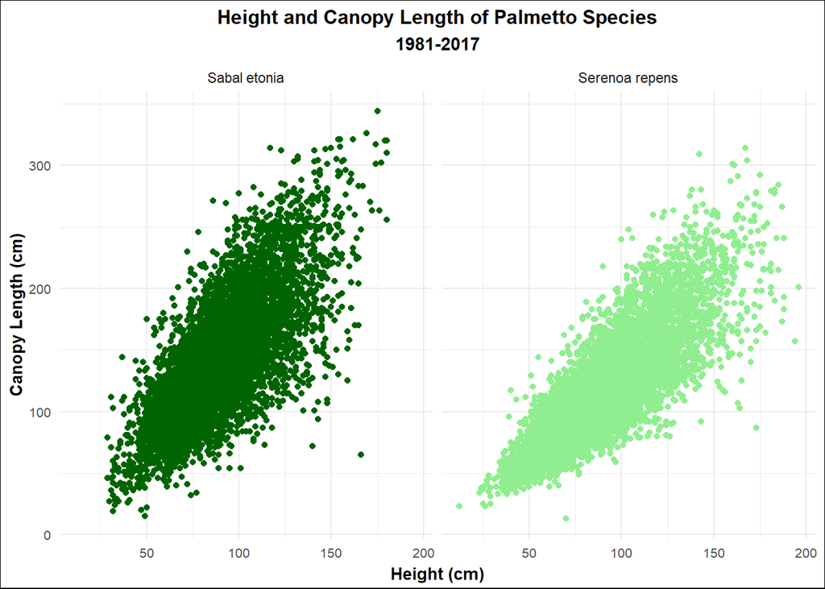

```r
# use ggpairs to view variables
# ggpairs(palmetto_subset, aes(color = species))


# Detailed graphs for some variables
height_length_plot <- ggplot(data = palmetto_subset, aes(x = height, y = length)) +
  geom_point(aes(color = species), show.legend = FALSE) +
  facet_wrap(~species)+
  theme_minimal()+
  labs( x = "Height (cm)",
        y = "Canopy Length (cm)",
        title = "Height and Canopy Length of Palmetto Species",
        subtitle = "1981-2017")+
  theme(plot.title = element_text(hjust = 0.5, face = "bold", size = 12),
        plot.subtitle = element_text(hjust = 0.5, face = "bold", size = 11),
        axis.title.x = element_text(vjust = 0.2, face = "bold", size = 10),
        axis.title.y = element_text(face = "bold", size = 10),
        axis.text = element_text(size = 8),
        plot.background = element_rect(fill = "white"))+
  scale_color_manual(values = c("darkgreen", "lightgreen"))

  height_length_plot
```

**Figure 1: Height vs. Canopy Length of Palmetto Species.** Height and canopy length in centimeters of two different Palmetto species, *Sabel etonia* (dark green) and *Serenoa repens* (light green).

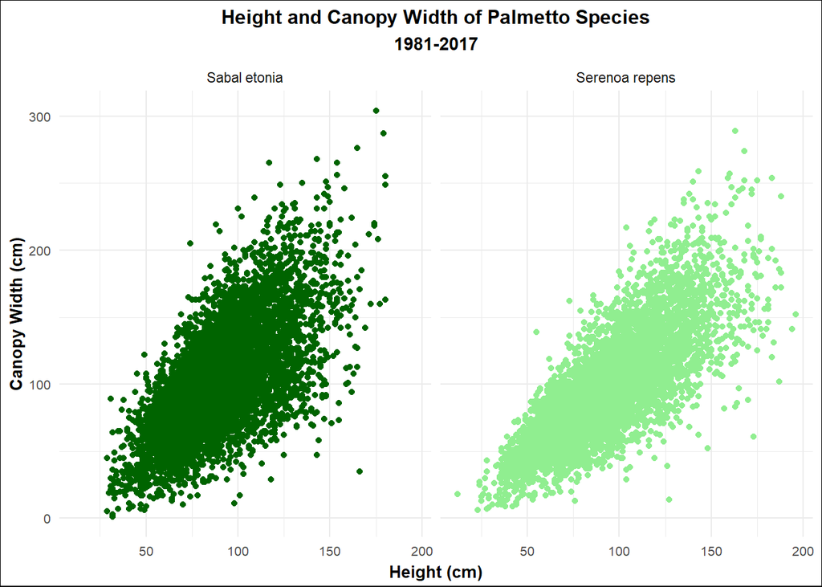

```r
height_width_plot <- ggplot(data = palmetto_subset, aes(x = height, y = width)) +
  geom_point(aes(color = species), show.legend = FALSE) +
  facet_wrap(~species)+
  theme_minimal()+
  labs( x = "Height (cm)",
        y = "Canopy Width (cm)",
        title = "Height and Canopy Width of Palmetto Species",
        subtitle = "1981-2017")+
  theme(plot.title = element_text(hjust = 0.5, face = "bold", size = 12),
        plot.subtitle = element_text(hjust = 0.5, face = "bold", size = 11),
        axis.title.x = element_text(vjust = 0.2, face = "bold", size = 10),
        axis.title.y = element_text(face = "bold", size = 10),
        axis.text = element_text(size = 8),
        plot.background = element_rect(fill = "white"))+
  scale_color_manual(values = c("darkgreen", "lightgreen"))

height_width_plot
```

**Figure 2: Height vs. Canopy Width of Palmetto Species.** Height and canopy width in centimeters of two different Palmetto species, *Sabel etonia* (dark green) and *Serenoa repens* (light green).

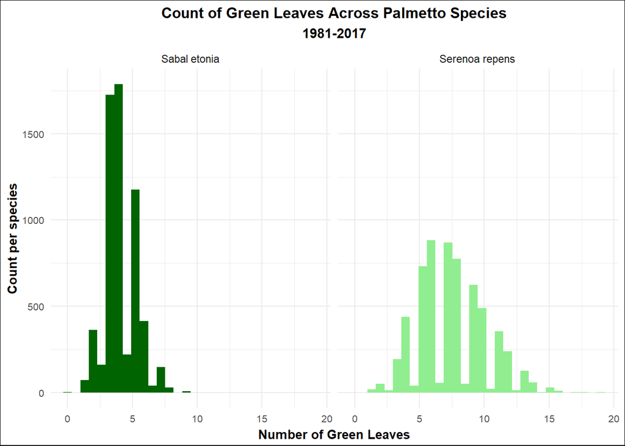

```r
height_lvs_plot <- ggplot(data = palmetto_subset, aes(x = green_lvs, fill = species)) +
  geom_histogram() +
  facet_wrap(~species)+
  theme_minimal()+
  labs( x = "Number of Green Leaves",
        y = "Count per species",
        title = "Count of Green Leaves Across Palmetto Species",
        subtitle = "1981-2017")+
  theme(plot.title = element_text(hjust = 0.5, face = "bold", size = 12),
        plot.subtitle = element_text(hjust = 0.5, face = "bold", size = 11),
        axis.title.x = element_text(vjust = 0.2, face = "bold", size = 10),
        axis.title.y = element_text(face = "bold", size = 10),
        axis.text = element_text(size = 8),
        plot.background = element_rect(fill = "white"),
        legend.position = "none")+
  scale_fill_manual(values = c("darkgreen", "lightgreen"))

height_lvs_plot
```

**Figure 3: Number of Plants with Green Leaf Counts.** A histogram displaying the count of plants that have varying numbers of green leaves of two different Palmetto species, *Sabel etonia* (dark green) and *Serenoa repens* (light green).

Based on the plots above, and the visible difference between the two species, one could see that the count of green leaves would have the highest likelihood of classifying species correctly. Canopy length, width, and height are all fairly similar across the two species, however, length may be slightly better in predicting species.